# Computational Statistic - Homework 1

Prof: Luiz Peternelli

Author

Marco Guerra Hinostroza

Published

September 25, 2024

# Theoretical questions

### **Q1. How is $\beta_i (i \neq 0)$ interpreted in simple linear regression and multiple linear regression?**

**Simple Linear Regression**
$$y = \beta_0 + \beta_{1}x_1 + \epsilon$$
*Interpretation*
$β_i$ is the slope, i.e. the average increase in $y$ associated with a one-unit increase in $x$.

**Multiple Linear Regression**
$$y = \beta_0 + \beta_{1}x_{1} + \beta_{2}x_{2} + \dots + \beta_{p}x_{p} + \epsilon$$
*Interpretation*
$β_i$ is the average eﬀect on $y$ of a one unit increase in $x_i$, holding all other predictors ﬁxed.

### **Q2. What is the difference between the residual standard error (RSE) and the $R^2$ statistic?**

The RSE is an estimate of the standard deviation of $\epsilon$. The RSE provides an absolute measure of the model’s lack of ﬁt to the data. But because it is measured in units of $y$ it can be confusing to interpret. The $R^2$ statistic provides an alternative measure of ﬁt. It takes the form of a ratio, the proportion of variance explained, so it always takes a value between 0 and 1, and is independent of the $y$ scale.

### **Q3. Why is the application of F-statistics in multiple linear regression more appropriate?**

It is more appropriate when we have many predicted variables. For example, $p = 100$ and $Ho : β_1 = β_2 = .... = β_p = 0$ is true, so no variable is actually associated with the response. In this situation, approximately 5% of the p-values associated with each variable will be below 0.05 by chance. Therefore, if we use the individual t-statistics and the associated p-values to decide whether or not there is any association between the variables and the response, there is a very high probability that we will incorrectly conclude that there is a relationship. However, the F statistic is not affected by this problem because it adjusts for the number of predictors. Therefore, if Ho is true, there is only a 5% chance that the F-statistic will result in a p-value of less than 0.05, regardless of the number of predictors or the number of observations.

$$F = \frac{{(TSS - RSS)}/{p}}{{RSS}/{(n - p - 1)}}$$

### **Q4. Deciding on Important Variables**

Forward selection

We start with a model that has only the intercept. We then fit p simple linear regressions and add to the null model the variable that results in the lowest RSS.

Backward selection

We start with all variables in the model and eliminate the variable with the highest p-value. We fit the new model of (p - 1) variables and eliminate the variable with the highest p-value. This procedure continues until a stopping rule is reached. For example, we can stop when all remaining variables have a p-value below some threshold.

Mixed selection

We start with no variables in the model by adding the variables one by one. The p-values of the variables may increase as new predictors are added to the model. Therefore, if at any point the p-value of one of the variables in the model exceeds a certain threshold, we remove that variable from the model. We continue these steps back and forth until all variables in the model have a sufficiently low p-value and all variables outside the model would have a high p-value if they were added to the model.

### **Q5. Outliers that have little effect on the model fit do not cause any problems?**

An outlier that does not have much eﬀect on the fit of the model may cause other problems. For example, it may overestimate the RSE value if the outlier is not removed. Since the RSE is used to calculate all conﬁdence intervals and p-values, a drastic increase caused by a single data point may have implications for the interpretation of the fit.

# Practical questions

### **Q6. Evaluating the association between X and Y**

```r
data("reid.grasses")
data <- reid.grasses
```

$$y_i = \beta_0 + \beta_{1}x_i + \epsilon$$
Where $\beta_0$ is the intercept, $\beta_1$ is the effect of the nitrogen level, and $\epsilon$ is the effect of error.

```r
model <- lm(drymatter ~ nitro, data = data)
```

Hypothesis testing

Ho : There is no relationship between X and Y ($\beta_1$ $=$ 0).

Ha : There is some relationship between X and Y ($\beta_1$ $\neq$ 0).

We use the t-statistic, t-statistic given by

$$t = \frac{\hat{\beta_1} - 0}{SE(\hat{\beta_1})}$$

$$\hat{\beta_1} = \frac{\sum_{i=1}^{n}(x_i - \bar{x})(y_i - \bar{y})}{\sum_{i=1}^{n}(x_i - \bar{x})^2}$$

$$SE(\hat{\beta_1}) = \sqrt{\frac{\sigma^2}{\sum_{i=1}^{n}(x_i - \bar{x})^2}}$$

```r
# Calculate β1 manually using the formula
nitro_mean <- mean(data$nitro)
drymatter_mean <- mean(data$drymatter)
beta1 <- sum((data$nitro - nitro_mean)*(data$drymatter - drymatter_mean)) /
  sum((data$nitro - nitro_mean)^2)

# Calculate σ²
residuals <- model$residuals
n <- length(residuals)  # number of observations
p <- length(coef(model))  # number of parameters (including intercept)
observed_values <- model$model$drymatter
predicted_values <- fitted(model)
sigma2 <- sum((observed_values - predicted_values)^2)/(n - p)

# Calculate SE(β1)
se_beta1 <- sqrt(sigma2 / sum((data$nitro - nitro_mean)^2))

# Calculate t-statistic
t_statistic <- (beta1 - 0) / se_beta1
t_statistic
```

```
[1] 19.91305
```

Considering a significance level of 0.001.

```r
# Critical t-value for a two-tailed test
t_crt <- qt(1 - 0.001/2, n - 2)
t_crt
```

```
[1] 3.337914
```

Conclusion  
At a significance level of 0.001 we reject the Ho. Therefore, there is an association between nitrogen level and dry matter.

### **Q7. Estimate the model fit with $R^2$**

To calculate $R^2$, we use the formula

$$R^2 = \frac{TSS - RSS}{TSS} = 1 - \frac{\sum(y_i - \hat{y}_i)^2}{\sum(y_i - \bar{y})^2}$$
Where $y_i$ is the i-th observed response value, $\hat{y}_i$ is the i-th predicted response value, and $\bar{y}$ is the mean of the observed values.

```r
observed_values <- model$model$drymatter
predicted_values <- fitted(model)

# Total Sum of Squares (TSS)
tss <- sum((observed_values - mean(observed_values))^2)

# Residual Sum of Squares (RSS)
rss <- sum((observed_values - predicted_values)^2)

# R^2
R2 <- 1 - (rss / tss)
R2
```

```
[1] 0.6559308
```

Summary of results of the fitted model

```r
summary(model)
```

```
Call:
lm(formula = drymatter ~ nitro, data = data)

Residuals:
    Min      1Q  Median      3Q     Max
-6.4794 -1.5725  0.1219  1.5597  5.0651

Coefficients:
             Estimate Std. Error t value Pr(>|t|)
(Intercept) 4.6444354  0.2450642   18.95   <2e-16 ***
nitro       0.0116573  0.0005854   19.91   <2e-16 ***
---
Signif. codes:  0 '***' 0.001 '**' 0.01 '*' 0.05 '.' 0.1 ' ' 1

Residual standard error: 2.118 on 208 degrees of freedom
Multiple R-squared:  0.6559,    Adjusted R-squared:  0.6543
F-statistic: 396.5 on 1 and 208 DF,  p-value: < 2.2e-16
```

### **Q8. Scatter plot and correlation matrix on a data set used for MLR**

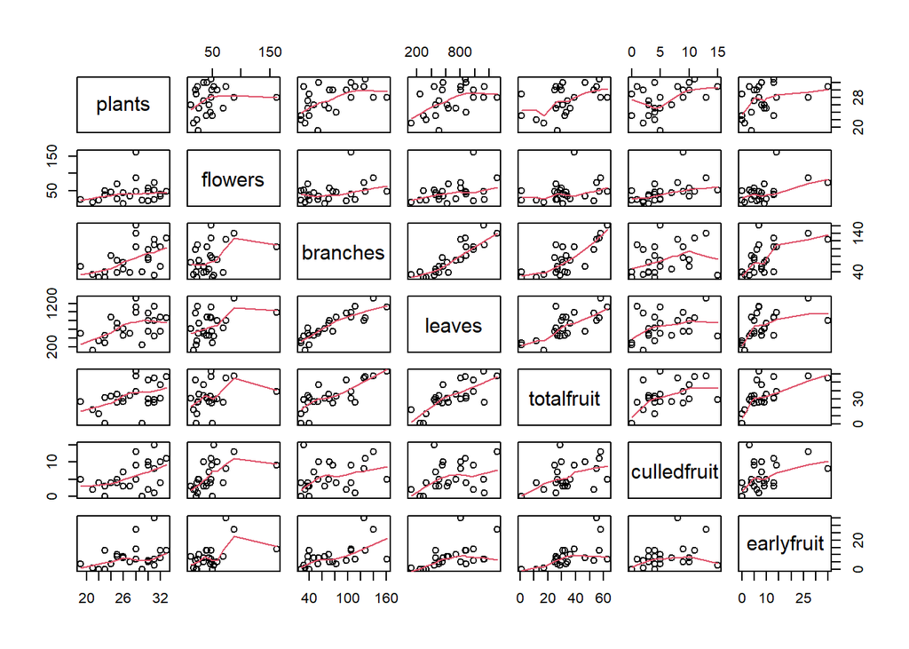

```r
data("cramer.cucumber")
data2 <- cramer.cucumber

pairs(data2[3:9],panel=panel.smooth)
```

```r
cor(data2[3:9])
```

```
               plants   flowers  branches    leaves totalfruit culledfruit
plants      1.0000000 0.2034658 0.5168255 0.4714659  0.4579666   0.4521424
flowers     0.2034658 1.0000000 0.3567711 0.4106342  0.2948946   0.4896926
branches    0.5168255 0.3567711 1.0000000 0.8868928  0.7815664   0.2887243
leaves      0.4714659 0.4106342 0.8868928 1.0000000  0.7432875   0.2967904
totalfruit  0.4579666 0.2948946 0.7815664 0.7432875  1.0000000   0.5022646
culledfruit 0.4521424 0.4896926 0.2887243 0.2967904  0.5022646   1.0000000
earlyfruit  0.3460632 0.4823337 0.6121214 0.5481865  0.6509378   0.4064236
            earlyfruit
plants       0.3460632
flowers      0.4823337
branches     0.6121214
leaves       0.5481865
totalfruit   0.6509378
culledfruit  0.4064236
earlyfruit   1.0000000
```

### **Q9. Relationship in Multiple Linear Regression**

```r
modelcucumber <- lm(earlyfruit ~ plants + flowers + branches + leaves + totalfruit + culledfruit , data = data2)

summary(modelcucumber)
```

```
Call:
lm(formula = earlyfruit ~ plants + flowers + branches + leaves +
    totalfruit + culledfruit, data = data2)

Residuals:
     Min       1Q   Median       3Q      Max
-12.1017  -2.9926  -0.8209   2.4376  16.1158

Coefficients:
             Estimate Std. Error t value Pr(>|t|)
(Intercept) -4.429667  10.799372  -0.410    0.687
plants       0.024413   0.448632   0.054    0.957
flowers      0.086639   0.055405   1.564    0.136
branches     0.067715   0.084740   0.799    0.435
leaves      -0.006058   0.009940  -0.610    0.550
totalfruit   0.235563   0.155914   1.511    0.149
culledfruit -0.051234   0.486011  -0.105    0.917

Residual standard error: 6.455 on 17 degrees of freedom
Multiple R-squared:  0.537, Adjusted R-squared:  0.3735
F-statistic: 3.286 on 6 and 17 DF,  p-value: 0.02474
```

*Is there a relationship between the predictors and the response?*

Although the F-statistic is close to 1, the p-value is less than 0.05 indicating that at least one of the predictors is related to the response variable.

### **Q10. SLR with discrete variable**

**Calculate the estimated values of the categories**

```r
mdmodel <- lm(drymatter ~ gen, data = data)
summary(mdmodel)
```

```
Call:
lm(formula = drymatter ~ gen, data = data)

Residuals:
    Min      1Q  Median      3Q     Max
-7.8967 -2.6842  0.5473  2.5827  6.4133

Coefficients:
            Estimate Std. Error t value Pr(>|t|)
(Intercept)  9.03119    0.55215  16.356   <2e-16 ***
genS.24     -0.01452    0.71282  -0.020   0.9838
genS.37     -0.49389    0.71282  -0.693   0.4892
genS.53     -1.58690    0.78086  -2.032   0.0434 *
---
Signif. codes:  0 '***' 0.001 '**' 0.01 '*' 0.05 '.' 0.1 ' ' 1

Residual standard error: 3.578 on 206 degrees of freedom
Multiple R-squared:  0.02757,   Adjusted R-squared:  0.01341
F-statistic: 1.947 on 3 and 206 DF,  p-value: 0.1232
```

```r
contrasts(data$gen)
```

```
          S.24 S.37 S.53
Barvestra    0    0    0
S.24         1    0    0
S.37         0    1    0
S.53         0    0    1
```

```r
mdmodel$coefficients
```

```
(Intercept)     genS.24     genS.37     genS.53
 9.03119048 -0.01452381 -0.49388889 -1.58690476
```

```r
estimated <- tibble(
  Genotype = c("Barvestra", "genS.24", "genS.37", "genS.53"),
  Value = c(
    mdmodel$coefficients[1],  # Barvestra (intercept)
    mdmodel$coefficients[1] + mdmodel$coefficients[2],  # genS.24
    mdmodel$coefficients[1] + mdmodel$coefficients[3],  # genS.37
    mdmodel$coefficients[1] + mdmodel$coefficients[4]   # genS.53
  )
)

estimated
```

```
# A tibble: 4 × 2
  Genotype  Value
  <chr>     <dbl>
1 Barvestra  9.03
2 genS.24    9.02
3 genS.37    8.54
4 genS.53    7.44
```

# Writing Functions

```r
ztest <- function(data, mu, sigma2) {
  n <- length(data)

  sample_mean <- mean(data)

  sigma <- sqrt(sigma2)

  z_value <- (sample_mean - mu) / (sigma / sqrt(n))

  p_value <- 2 * pnorm(-abs(z_value))

  result <- list(
    data = data,
    sample_mean = sample_mean,
    H0_mu = mu,
    p_value = p_value
  )

  return(result)
}
```

```r
mod <- ztest(data = data$drymatter, mu = 8.3, sigma2 = 1.2)

mod
```

```
$data
  [1]  1.58  2.71  4.14  4.76  8.61  6.34  7.30  8.08  9.94  9.94 12.02 13.30
 [13] 10.82 12.20 14.02 15.10 13.38 13.68 14.04 14.57 15.43  2.74  3.11  4.88
 [25]  8.03  7.30  8.21  8.60  9.04  9.08 10.63  9.99 10.63 11.98 12.50 12.91
 [37] 13.97 12.39 13.96 14.31 14.63 14.52  1.33  1.86  3.92  4.93  5.70  5.95
 [49]  6.71  8.48  8.28  8.81  9.79 10.36 11.14 10.95 11.42 12.21 12.47 13.22
 [61] 12.29 13.30 13.37  2.01  2.74  3.27  4.37  5.95  6.59  7.73  8.43  8.69
 [73]  8.92  9.99 11.00 11.05 10.84 11.73 11.11 11.33 11.77 11.95 11.74 11.85
 [85]  1.12  1.99  2.51  3.13  4.53  4.56  5.75  6.16  7.07  7.95  8.23  8.37
 [97]  8.67  9.18 10.92 10.99 10.76 10.03  9.94  8.55 10.47  1.50  2.50  3.00
[109]  4.37  4.63  5.30  5.91  7.28  7.98  8.17  9.09  9.50  9.62 10.72 10.73
[121] 10.87 10.29 11.22 11.23 10.46 11.53  1.31  2.18  3.41  4.93  5.36  5.25
[133]  5.58  7.65  7.46  9.31  8.18 10.14 10.30  9.48  9.93 10.94 10.27 10.49
[145] 10.58 10.41 10.18  2.14  1.43  2.82  3.08  3.92  4.17  4.91  5.05  6.17
[157]  6.00  7.95  7.66  7.42  7.81  7.86  7.90  8.08  9.23  9.17  8.22  8.61
[169]  2.37  2.79  4.30  4.76  6.49  6.33  7.32  8.12  9.05 10.30 10.81 11.19
[181] 11.55 12.43 14.38 14.32 13.47 14.00 13.97 13.31 13.95  2.42  3.12  4.23
[193]  4.93  6.53  6.16  6.54  8.23  8.10  9.66  9.41 11.19 11.12 11.04 11.12
[205] 11.56 12.04 12.45 12.77 12.24 13.16

$sample_mean
[1] 8.561286

$H0_mu
[1] 8.3

$p_value
[1] 0.0005472695
```